# Análise da Arrecadação de Imposto de Importação (II) e IPI Vinculado sobre as Importações Brasileiras

## Importações e Arrecadação como % do PIB

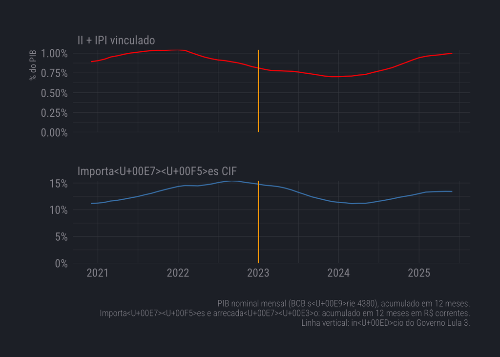

```r
ii_ipi_comex%>%
  filter(!is.na(imp_pct_pib_12))%>%
  tidyr::pivot_longer(cols = c(imp_pct_pib_12, ii_ipi_pct_pib_12),
                      names_to = "serie",
                      values_to = "pct_pib")%>%
  mutate(serie = dplyr::recode(serie,
    imp_pct_pib_12 = "Importações CIF",
    ii_ipi_pct_pib_12 = "II + IPI vinculado"))%>%
  ggplot(aes(x=date, y=pct_pib)) +
  geom_line(aes(color=serie)) +
  geom_vline(xintercept=as.Date("2023-01-01"), color="orange") +
  facet_wrap(~serie, scales="free_y", ncol=1) +
  hrbrthemes::theme_ft_rc() +
  scale_color_manual(values=c("Importações CIF"="steelblue", "II + IPI vinculado"="red"), guide="none") +
  scale_y_continuous("% do PIB", labels=scales::percent, limits=c(0,NA), expand=c(0,0)) +
  labs(x="", caption = "PIB nominal mensal (BCB série 4380), acumulado em 12 meses.\nImportações e arrecadação: acumulado em 12 meses em R$ correntes.\nLinha vertical: início do Governo Lula 3.")
```

## Visualização da Proporção do Imposto

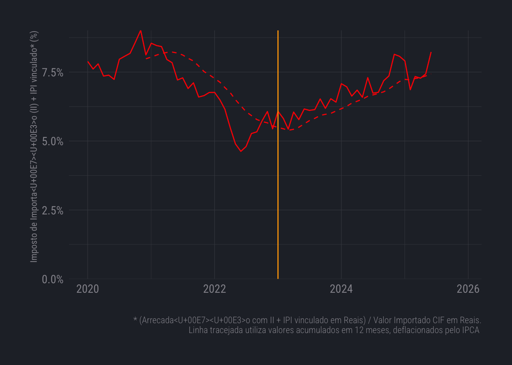

```r
ggplot(data=ii_ipi_comex, aes(x=date, y=ii_prop)) +
  geom_line(color="red") +
  geom_line(aes(y=ii_prop_12), linetype=2, color="red") +
  geom_vline(xintercept=as.Date("2023-01-01"), color="orange") +
  hrbrthemes::theme_ft_rc() +
  scale_y_continuous("Imposto de Importação (II) + IPI vinculado* (%)", limits=c(0,NA), expand=c(0,0), labels = scales::percent) +
  labs(x="", caption = "* (Arrecadação com II + IPI vinculado em Reais) / Valor Importado CIF em Reais.\nLinha tracejada utiliza valores acumulados em 12 meses, deflacionados pelo IPCA ")
```

A virada ocorre a partir de 2023, impulsionada por dois fatores combinados. O primeiro é de composição: a normalização do mix de importações, com menor participação de commodities energéticas e insumos desonerados e maior peso de bens de consumo sujeitos a alíquotas padrão. O segundo, e igualmente importante, é de política tarifária: o Governo Lula III promoveu um aumento deliberado da proteção tarifária. Em dezembro de 2023 deixou expirar uma redução linear de 10% sobre as alíquotas do II que havia sido adotada como medida antiinflacionária em 2022. Além disso, houve diversas alterações pontuais de alíquotas via LETEC (Lista de Exceções à Tarifa Externa Comum do Mercosul) e LEBITBK (Lista de Bens de Informática, de Telecomunicações, e de Bens de Capital), reduzindo a abrangência dos regimes especiais que beneficiavam bens de capital e tecnologia. O conjunto dessas mudanças elevou as alíquotas nominais vigentes sobre uma parcela relevante da pauta de importações.

**O que isso significa na prática?** Para cada R$ 100 de produto importado, consumidores e empresas pagam hoje R$ 7,40 em II e IPI vinculado — contra R$ 5,00 no pior momento de 2022. Com importações anuais na casa de R$ 1,65 trilhão, esse aumento de 2,4 pontos percentuais na alíquota efetiva representa cerca de R$ 40 bilhões a mais no custo de importar produtos do exterior — aproximadamente 0,3% do PIB.